# Risk Factor Analysis

## Outcome Variable

**Outcome Variable:** ever_co

## Predictor Variables

**Intervention Variable:** earlybf

**Adjustment Set:**

unadjusted

## Stratifying Variables

The analysis was stratified on these variable(s):

- agecat
- studyid
- country

## Data Summary

| agecat | studyid | country | earlybf | ever_co | n_cell | n |
| --- | --- | --- | --- | --- | --- | --- |
| 0-24 months | ki0047075b-MAL-ED | BANGLADESH | 1 | 0 | 140 | 262 |
| 0-24 months | ki0047075b-MAL-ED | BANGLADESH | 1 | 1 | 21 | 262 |
| 0-24 months | ki0047075b-MAL-ED | BANGLADESH | 0 | 0 | 84 | 262 |
| 0-24 months | ki0047075b-MAL-ED | BANGLADESH | 0 | 1 | 17 | 262 |
| 0-24 months | ki0047075b-MAL-ED | BRAZIL | 1 | 0 | 107 | 233 |
| 0-24 months | ki0047075b-MAL-ED | BRAZIL | 1 | 1 | 1 | 233 |
| 0-24 months | ki0047075b-MAL-ED | BRAZIL | 0 | 0 | 123 | 233 |
| 0-24 months | ki0047075b-MAL-ED | BRAZIL | 0 | 1 | 2 | 233 |
| 0-24 months | ki0047075b-MAL-ED | INDIA | 1 | 0 | 115 | 250 |
| 0-24 months | ki0047075b-MAL-ED | INDIA | 1 | 1 | 33 | 250 |
| 0-24 months | ki0047075b-MAL-ED | INDIA | 0 | 0 | 81 | 250 |
| 0-24 months | ki0047075b-MAL-ED | INDIA | 0 | 1 | 21 | 250 |
| 0-24 months | ki0047075b-MAL-ED | NEPAL | 1 | 0 | 89 | 240 |
| 0-24 months | ki0047075b-MAL-ED | NEPAL | 1 | 1 | 9 | 240 |
| 0-24 months | ki0047075b-MAL-ED | NEPAL | 0 | 0 | 129 | 240 |
| 0-24 months | ki0047075b-MAL-ED | NEPAL | 0 | 1 | 13 | 240 |
| 0-24 months | ki0047075b-MAL-ED | PERU | 1 | 0 | 214 | 302 |
| 0-24 months | ki0047075b-MAL-ED | PERU | 1 | 1 | 11 | 302 |
| 0-24 months | ki0047075b-MAL-ED | PERU | 0 | 0 | 76 | 302 |
| 0-24 months | ki0047075b-MAL-ED | PERU | 0 | 1 | 1 | 302 |
| 0-24 months | ki0047075b-MAL-ED | SOUTH AFRICA | 1 | 0 | 169 | 297 |
| 0-24 months | ki0047075b-MAL-ED | SOUTH AFRICA | 1 | 1 | 12 | 297 |
| 0-24 months | ki0047075b-MAL-ED | SOUTH AFRICA | 0 | 0 | 105 | 297 |
| 0-24 months | ki0047075b-MAL-ED | SOUTH AFRICA | 0 | 1 | 11 | 297 |
| 0-24 months | ki0047075b-MAL-ED | TANZANIA, UNITED REPUBLIC OF | 1 | 0 | 197 | 261 |
| 0-24 months | ki0047075b-MAL-ED | TANZANIA, UNITED REPUBLIC OF | 1 | 1 | 19 | 261 |
| 0-24 months | ki0047075b-MAL-ED | TANZANIA, UNITED REPUBLIC OF | 0 | 0 | 41 | 261 |
| 0-24 months | ki0047075b-MAL-ED | TANZANIA, UNITED REPUBLIC OF | 0 | 1 | 4 | 261 |
| 0-24 months | ki1000109-EE | PAKISTAN | 1 | 0 | 40 | 367 |
| 0-24 months | ki1000109-EE | PAKISTAN | 1 | 1 | 29 | 367 |

[output cut: 138 more lines]

The following strata were considered:

- agecat: 0-24 months, studyid: ki0047075b-MAL-ED, country: BANGLADESH
- agecat: 0-24 months, studyid: ki0047075b-MAL-ED, country: BRAZIL
- agecat: 0-24 months, studyid: ki0047075b-MAL-ED, country: INDIA
- agecat: 0-24 months, studyid: ki0047075b-MAL-ED, country: NEPAL
- agecat: 0-24 months, studyid: ki0047075b-MAL-ED, country: PERU
- agecat: 0-24 months, studyid: ki0047075b-MAL-ED, country: SOUTH AFRICA
- agecat: 0-24 months, studyid: ki0047075b-MAL-ED, country: TANZANIA, UNITED REPUBLIC OF
- agecat: 0-24 months, studyid: ki1000109-EE, country: PAKISTAN
- agecat: 0-24 months, studyid: ki1000304b-SAS-CompFeed, country: INDIA
- agecat: 0-24 months, studyid: ki1017093c-NIH-Crypto, country: BANGLADESH
- agecat: 0-24 months, studyid: ki1113344-GMS-Nepal, country: NEPAL
- agecat: 0-24 months, studyid: ki1126311-ZVITAMBO, country: ZIMBABWE
- agecat: 0-24 months, studyid: kiGH5241-JiVitA-3, country: BANGLADESH
- agecat: 0-24 months, studyid: kiGH5241-JiVitA-4, country: BANGLADESH
- agecat: 0-6 months, studyid: ki0047075b-MAL-ED, country: BANGLADESH
- agecat: 0-6 months, studyid: ki0047075b-MAL-ED, country: BRAZIL
- agecat: 0-6 months, studyid: ki0047075b-MAL-ED, country: INDIA
- agecat: 0-6 months, studyid: ki0047075b-MAL-ED, country: NEPAL
- agecat: 0-6 months, studyid: ki0047075b-MAL-ED, country: PERU
- agecat: 0-6 months, studyid: ki0047075b-MAL-ED, country: SOUTH AFRICA
- agecat: 0-6 months, studyid: ki0047075b-MAL-ED, country: TANZANIA, UNITED REPUBLIC OF
- agecat: 0-6 months, studyid: ki1000109-EE, country: PAKISTAN
- agecat: 0-6 months, studyid: ki1000304b-SAS-CompFeed, country: INDIA
- agecat: 0-6 months, studyid: ki1017093c-NIH-Crypto, country: BANGLADESH
- agecat: 0-6 months, studyid: ki1113344-GMS-Nepal, country: NEPAL
- agecat: 0-6 months, studyid: ki1126311-ZVITAMBO, country: ZIMBABWE
- agecat: 0-6 months, studyid: kiGH5241-JiVitA-3, country: BANGLADESH
- agecat: 0-6 months, studyid: kiGH5241-JiVitA-4, country: BANGLADESH
- agecat: 6-24 months, studyid: ki0047075b-MAL-ED, country: BANGLADESH
- agecat: 6-24 months, studyid: ki0047075b-MAL-ED, country: BRAZIL
- agecat: 6-24 months, studyid: ki0047075b-MAL-ED, country: INDIA
- agecat: 6-24 months, studyid: ki0047075b-MAL-ED, country: NEPAL
- agecat: 6-24 months, studyid: ki0047075b-MAL-ED, country: PERU
- agecat: 6-24 months, studyid: ki0047075b-MAL-ED, country: SOUTH AFRICA
- agecat: 6-24 months, studyid: ki0047075b-MAL-ED, country: TANZANIA, UNITED REPUBLIC OF
- agecat: 6-24 months, studyid: ki1000109-EE, country: PAKISTAN
- agecat: 6-24 months, studyid: ki1000304b-SAS-CompFeed, country: INDIA
- agecat: 6-24 months, studyid: ki1017093c-NIH-Crypto, country: BANGLADESH
- agecat: 6-24 months, studyid: ki1113344-GMS-Nepal, country: NEPAL
- agecat: 6-24 months, studyid: ki1126311-ZVITAMBO, country: ZIMBABWE
- agecat: 6-24 months, studyid: kiGH5241-JiVitA-3, country: BANGLADESH
- agecat: 6-24 months, studyid: kiGH5241-JiVitA-4, country: BANGLADESH

### Dropped Strata

Some strata were dropped due to rare outcomes:

- agecat: 0-24 months, studyid: ki0047075b-MAL-ED, country: BRAZIL
- agecat: 0-24 months, studyid: ki0047075b-MAL-ED, country: PERU
- agecat: 0-24 months, studyid: ki0047075b-MAL-ED, country: TANZANIA, UNITED REPUBLIC OF
- agecat: 0-6 months, studyid: ki0047075b-MAL-ED, country: BANGLADESH
- agecat: 0-6 months, studyid: ki0047075b-MAL-ED, country: BRAZIL
- agecat: 0-6 months, studyid: ki0047075b-MAL-ED, country: NEPAL
- agecat: 0-6 months, studyid: ki0047075b-MAL-ED, country: PERU
- agecat: 0-6 months, studyid: ki0047075b-MAL-ED, country: SOUTH AFRICA
- agecat: 0-6 months, studyid: ki0047075b-MAL-ED, country: TANZANIA, UNITED REPUBLIC OF
- agecat: 0-6 months, studyid: ki1017093c-NIH-Crypto, country: BANGLADESH
- agecat: 6-24 months, studyid: ki0047075b-MAL-ED, country: BRAZIL
- agecat: 6-24 months, studyid: ki0047075b-MAL-ED, country: PERU
- agecat: 6-24 months, studyid: ki0047075b-MAL-ED, country: TANZANIA, UNITED REPUBLIC OF
- agecat: 6-24 months, studyid: ki1017093c-NIH-Crypto, country: BANGLADESH
- agecat: 6-24 months, studyid: kiGH5241-JiVitA-3, country: BANGLADESH

## Methods Detail

We’re interested in the causal parameters $E[Y_a]$ for all values of $a \in \mathcal{A}$. These parameters represent the mean outcome if, possibly contrary to fact, we intervened to set all units to have $A=a$. Under the randomization and positivity assumptions, these are identified by the statistical parameters $\psi_a=E_W[E_{Y|A,W}(Y|A=a,W)]$. In addition, we’re interested in the mean of $Y$, $E[Y]$ under no intervention (the observed mean). We will estimate these parameters by using SuperLearner to fit the relevant likelihood factors – $E_{Y|A,W}(Y|A=a,W)$ and $p(A=a|W)$, and then updating our likelihood fit using a joint TMLE.

For unadjusted analyses ($W=\{\}$), initial likelihoods were estimated using Lrnr_glm to estimate the simple $E(Y|A)$ and Lrnr_mean to estimate $p(A)$. For adjusted analyses, a small library containing Lrnr_glmnet, Lrnr_xgboost, and Lrnr_mean was used.

Having estimated these parameters, we will then use the delta method to estimate relative risks and attributable risks relative to a prespecified baseline level of $A$.

# Results Detail

## Results Plots

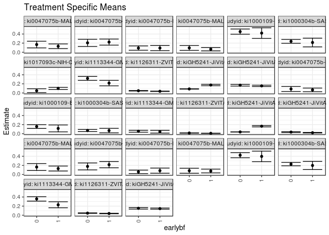

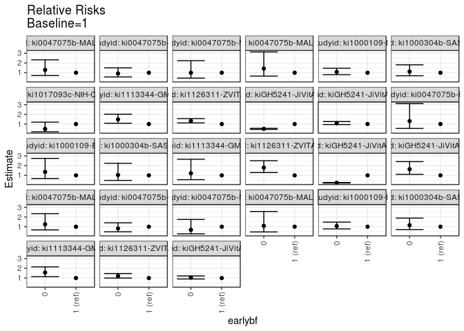

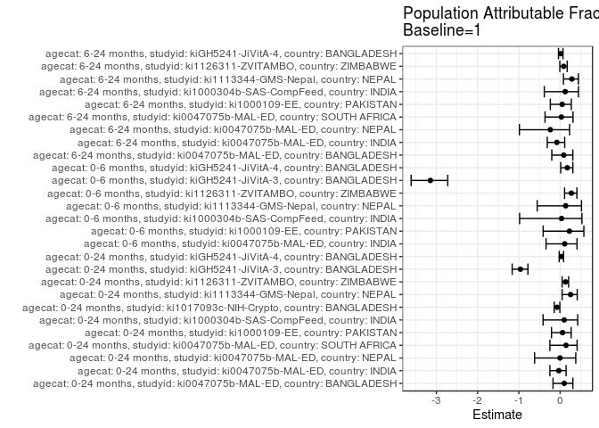

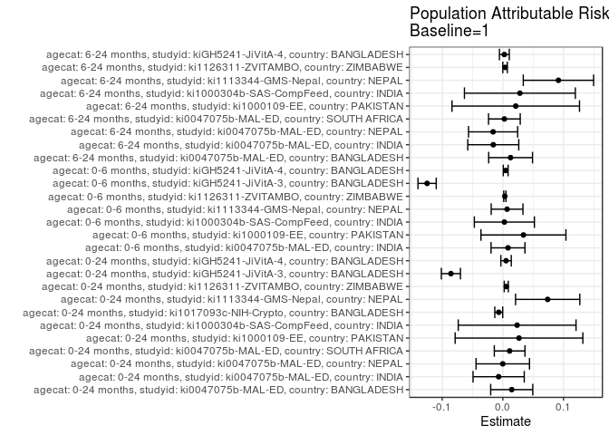

## Results Table

### Parameter: TSM

| agecat | studyid | country | intervention_level | baseline_level | estimate | ci_lower | ci_upper |
| --- | --- | --- | --- | --- | --- | --- | --- |
| 0-24 months | ki0047075b-MAL-ED | BANGLADESH | 1 | NA | 0.1304348 | 0.0783137 | 0.1825559 |
| 0-24 months | ki0047075b-MAL-ED | BANGLADESH | 0 | NA | 0.1683168 | 0.0952096 | 0.2414241 |
| 0-24 months | ki0047075b-MAL-ED | INDIA | 1 | NA | 0.2229730 | 0.1557788 | 0.2901672 |
| 0-24 months | ki0047075b-MAL-ED | INDIA | 0 | NA | 0.2058824 | 0.1272556 | 0.2845091 |
| 0-24 months | ki0047075b-MAL-ED | NEPAL | 1 | NA | 0.0918367 | 0.0345397 | 0.1491337 |
| 0-24 months | ki0047075b-MAL-ED | NEPAL | 0 | NA | 0.0915493 | 0.0440170 | 0.1390816 |
| 0-24 months | ki0047075b-MAL-ED | SOUTH AFRICA | 1 | NA | 0.0662983 | 0.0299908 | 0.1026059 |
| 0-24 months | ki0047075b-MAL-ED | SOUTH AFRICA | 0 | NA | 0.0948276 | 0.0414223 | 0.1482329 |
| 0-24 months | ki1000109-EE | PAKISTAN | 1 | NA | 0.4202899 | 0.3036637 | 0.5369160 |
| 0-24 months | ki1000109-EE | PAKISTAN | 0 | NA | 0.4530201 | 0.3964253 | 0.5096150 |
| 0-24 months | ki1000304b-SAS-CompFeed | INDIA | 1 | NA | 0.2135922 | 0.1179650 | 0.3092194 |
| 0-24 months | ki1000304b-SAS-CompFeed | INDIA | 0 | NA | 0.2388605 | 0.1960578 | 0.2816632 |
| 0-24 months | ki1017093c-NIH-Crypto | BANGLADESH | 1 | NA | 0.1004566 | 0.0774553 | 0.1234579 |
| 0-24 months | ki1017093c-NIH-Crypto | BANGLADESH | 0 | NA | 0.0495050 | 0.0071725 | 0.0918374 |
| 0-24 months | ki1113344-GMS-Nepal | NEPAL | 1 | NA | 0.2166667 | 0.1564343 | 0.2768990 |
| 0-24 months | ki1113344-GMS-Nepal | NEPAL | 0 | NA | 0.3205418 | 0.2770488 | 0.3640347 |
| 0-24 months | ki1126311-ZVITAMBO | ZIMBABWE | 1 | NA | 0.0368852 | 0.0323338 | 0.0414367 |
| 0-24 months | ki1126311-ZVITAMBO | ZIMBABWE | 0 | NA | 0.0487721 | 0.0432396 | 0.0543046 |
| 0-24 months | kiGH5241-JiVitA-3 | BANGLADESH | 1 | NA | 0.1746988 | 0.1593450 | 0.1900525 |
| 0-24 months | kiGH5241-JiVitA-3 | BANGLADESH | 0 | NA | 0.0885032 | 0.0844747 | 0.0925317 |
| 0-24 months | kiGH5241-JiVitA-4 | BANGLADESH | 1 | NA | 0.1560862 | 0.1417644 | 0.1704080 |
| 0-24 months | kiGH5241-JiVitA-4 | BANGLADESH | 0 | NA | 0.1703187 | 0.1518599 | 0.1887776 |
| 0-6 months | ki0047075b-MAL-ED | INDIA | 1 | NA | 0.0675676 | 0.0270479 | 0.1080872 |
| 0-6 months | ki0047075b-MAL-ED | INDIA | 0 | NA | 0.0882353 | 0.0330808 | 0.1433898 |
| 0-6 months | ki1000109-EE | PAKISTAN | 1 | NA | 0.1159420 | 0.0402976 | 0.1915864 |
| 0-6 months | ki1000109-EE | PAKISTAN | 0 | NA | 0.1577181 | 0.1162798 | 0.1991564 |
| 0-6 months | ki1000304b-SAS-CompFeed | INDIA | 1 | NA | 0.0686275 | 0.0186437 | 0.1186112 |
| 0-6 months | ki1000304b-SAS-CompFeed | INDIA | 0 | NA | 0.0712711 | 0.0481167 | 0.0944255 |
| 0-6 months | ki1113344-GMS-Nepal | NEPAL | 1 | NA | 0.0444444 | 0.0143146 | 0.0745743 |
| 0-6 months | ki1113344-GMS-Nepal | NEPAL | 0 | NA | 0.0541761 | 0.0330799 | 0.0752723 |
| 0-6 months | ki1126311-ZVITAMBO | ZIMBABWE | 1 | NA | 0.0085496 | 0.0063199 | 0.0107794 |
| 0-6 months | ki1126311-ZVITAMBO | ZIMBABWE | 0 | NA | 0.0154086 | 0.0122320 | 0.0185852 |
| 0-6 months | kiGH5241-JiVitA-3 | BANGLADESH | 1 | NA | 0.1646341 | 0.1496232 | 0.1796451 |
| 0-6 months | kiGH5241-JiVitA-3 | BANGLADESH | 0 | NA | 0.0389493 | 0.0363766 | 0.0415220 |
| 0-6 months | kiGH5241-JiVitA-4 | BANGLADESH | 1 | NA | 0.0218612 | 0.0159257 | 0.0277966 |
| 0-6 months | kiGH5241-JiVitA-4 | BANGLADESH | 0 | NA | 0.0357352 | 0.0253163 | 0.0461541 |
| 6-24 months | ki0047075b-MAL-ED | BANGLADESH | 1 | NA | 0.1301370 | 0.0754465 | 0.1848275 |
| 6-24 months | ki0047075b-MAL-ED | BANGLADESH | 0 | NA | 0.1630435 | 0.0874000 | 0.2386870 |
| 6-24 months | ki0047075b-MAL-ED | INDIA | 1 | NA | 0.2158273 | 0.1472902 | 0.2843644 |
| 6-24 months | ki0047075b-MAL-ED | INDIA | 0 | NA | 0.1770833 | 0.1005580 | 0.2536087 |
| 6-24 months | ki0047075b-MAL-ED | NEPAL | 1 | NA | 0.0842105 | 0.0282485 | 0.1401725 |
| 6-24 months | ki0047075b-MAL-ED | NEPAL | 0 | NA | 0.0571429 | 0.0186115 | 0.0956742 |
| 6-24 months | ki0047075b-MAL-ED | SOUTH AFRICA | 1 | NA | 0.0759494 | 0.0345606 | 0.1173382 |
| 6-24 months | ki0047075b-MAL-ED | SOUTH AFRICA | 0 | NA | 0.0824742 | 0.0276233 | 0.1373251 |
| 6-24 months | ki1000109-EE | PAKISTAN | 1 | NA | 0.3970588 | 0.2806031 | 0.5135146 |
| 6-24 months | ki1000109-EE | PAKISTAN | 0 | NA | 0.4232082 | 0.3665578 | 0.4798586 |
| 6-24 months | ki1000304b-SAS-CompFeed | INDIA | 1 | NA | 0.1980198 | 0.1080545 | 0.2879851 |
| 6-24 months | ki1000304b-SAS-CompFeed | INDIA | 0 | NA | 0.2282609 | 0.1905962 | 0.2659255 |
| 6-24 months | ki1113344-GMS-Nepal | NEPAL | 1 | NA | 0.2292994 | 0.1634809 | 0.2951179 |
| 6-24 months | ki1113344-GMS-Nepal | NEPAL | 0 | NA | 0.3588391 | 0.3105034 | 0.4071747 |
| 6-24 months | ki1126311-ZVITAMBO | ZIMBABWE | 1 | NA | 0.0378014 | 0.0326100 | 0.0429927 |
| 6-24 months | ki1126311-ZVITAMBO | ZIMBABWE | 0 | NA | 0.0456085 | 0.0394637 | 0.0517532 |
| 6-24 months | kiGH5241-JiVitA-4 | BANGLADESH | 1 | NA | 0.1452742 | 0.1317250 | 0.1588235 |
| 6-24 months | kiGH5241-JiVitA-4 | BANGLADESH | 0 | NA | 0.1519240 | 0.1347252 | 0.1691228 |

### Parameter: E(Y)

| agecat | studyid | country | intervention_level | baseline_level | estimate | ci_lower | ci_upper |
| --- | --- | --- | --- | --- | --- | --- | --- |
| 0-24 months | ki0047075b-MAL-ED | BANGLADESH | NA | NA | 0.1450382 | 0.1023171 | 0.1877593 |
| 0-24 months | ki0047075b-MAL-ED | INDIA | NA | NA | 0.2160000 | 0.1648868 | 0.2671132 |
| 0-24 months | ki0047075b-MAL-ED | NEPAL | NA | NA | 0.0916667 | 0.0550838 | 0.1282495 |
| 0-24 months | ki0047075b-MAL-ED | SOUTH AFRICA | NA | NA | 0.0774411 | 0.0469912 | 0.1078909 |
| 0-24 months | ki1000109-EE | PAKISTAN | NA | NA | 0.4468665 | 0.3959321 | 0.4978009 |
| 0-24 months | ki1000304b-SAS-CompFeed | INDIA | NA | NA | 0.2370924 | 0.1969570 | 0.2772278 |
| 0-24 months | ki1017093c-NIH-Crypto | BANGLADESH | NA | NA | 0.0936675 | 0.0729118 | 0.1144233 |
| 0-24 months | ki1113344-GMS-Nepal | NEPAL | NA | NA | 0.2905297 | 0.2548505 | 0.3262089 |
| 0-24 months | ki1126311-ZVITAMBO | ZIMBABWE | NA | NA | 0.0424623 | 0.0389147 | 0.0460100 |
| 0-24 months | kiGH5241-JiVitA-3 | BANGLADESH | NA | NA | 0.0890362 | 0.0851140 | 0.0929585 |
| 0-24 months | kiGH5241-JiVitA-4 | BANGLADESH | NA | NA | 0.1613377 | 0.1500062 | 0.1726692 |
| 0-6 months | ki0047075b-MAL-ED | INDIA | NA | NA | 0.0760000 | 0.0430852 | 0.1089148 |
| 0-6 months | ki1000109-EE | PAKISTAN | NA | NA | 0.1498638 | 0.1132959 | 0.1864317 |
| 0-6 months | ki1000304b-SAS-CompFeed | INDIA | NA | NA | 0.0710868 | 0.0489978 | 0.0931759 |
| 0-6 months | ki1113344-GMS-Nepal | NEPAL | NA | NA | 0.0513644 | 0.0340170 | 0.0687117 |
| 0-6 months | ki1126311-ZVITAMBO | ZIMBABWE | NA | NA | 0.0117638 | 0.0098602 | 0.0136673 |
| 0-6 months | kiGH5241-JiVitA-3 | BANGLADESH | NA | NA | 0.0397202 | 0.0372135 | 0.0422270 |
| 0-6 months | kiGH5241-JiVitA-4 | BANGLADESH | NA | NA | 0.0265122 | 0.0211694 | 0.0318550 |
| 6-24 months | ki0047075b-MAL-ED | BANGLADESH | NA | NA | 0.1428571 | 0.0983068 | 0.1874075 |
| 6-24 months | ki0047075b-MAL-ED | INDIA | NA | NA | 0.2000000 | 0.1487493 | 0.2512507 |
| 6-24 months | ki0047075b-MAL-ED | NEPAL | NA | NA | 0.0680851 | 0.0358110 | 0.1003592 |
| 6-24 months | ki0047075b-MAL-ED | SOUTH AFRICA | NA | NA | 0.0784314 | 0.0453685 | 0.1114942 |
| 6-24 months | ki1000109-EE | PAKISTAN | NA | NA | 0.4182825 | 0.3673274 | 0.4692377 |
| 6-24 months | ki1000304b-SAS-CompFeed | INDIA | NA | NA | 0.2260619 | 0.1909133 | 0.2612105 |
| 6-24 months | ki1113344-GMS-Nepal | NEPAL | NA | NA | 0.3208955 | 0.2813387 | 0.3604523 |
| 6-24 months | ki1126311-ZVITAMBO | ZIMBABWE | NA | NA | 0.0413980 | 0.0374157 | 0.0453802 |
| 6-24 months | kiGH5241-JiVitA-4 | BANGLADESH | NA | NA | 0.1477252 | 0.1371297 | 0.1583206 |

### Parameter: RR

| agecat | studyid | country | intervention_level | baseline_level | estimate | ci_lower | ci_upper |
| --- | --- | --- | --- | --- | --- | --- | --- |
| 0-24 months | ki0047075b-MAL-ED | BANGLADESH | 1 | 1 | 1.0000000 | 1.0000000 | 1.0000000 |
| 0-24 months | ki0047075b-MAL-ED | BANGLADESH | 0 | 1 | 1.2904290 | 0.7151806 | 2.3283728 |
| 0-24 months | ki0047075b-MAL-ED | INDIA | 1 | 1 | 1.0000000 | 1.0000000 | 1.0000000 |
| 0-24 months | ki0047075b-MAL-ED | INDIA | 0 | 1 | 0.9233512 | 0.5676633 | 1.5019068 |
| 0-24 months | ki0047075b-MAL-ED | NEPAL | 1 | 1 | 1.0000000 | 1.0000000 | 1.0000000 |
| 0-24 months | ki0047075b-MAL-ED | NEPAL | 0 | 1 | 0.9968701 | 0.4427226 | 2.2446334 |
| 0-24 months | ki0047075b-MAL-ED | SOUTH AFRICA | 1 | 1 | 1.0000000 | 1.0000000 | 1.0000000 |
| 0-24 months | ki0047075b-MAL-ED | SOUTH AFRICA | 0 | 1 | 1.4303161 | 0.6520389 | 3.1375491 |
| 0-24 months | ki1000109-EE | PAKISTAN | 1 | 1 | 1.0000000 | 1.0000000 | 1.0000000 |
| 0-24 months | ki1000109-EE | PAKISTAN | 0 | 1 | 1.0778755 | 0.7950717 | 1.4612714 |
| 0-24 months | ki1000304b-SAS-CompFeed | INDIA | 1 | 1 | 1.0000000 | 1.0000000 | 1.0000000 |
| 0-24 months | ki1000304b-SAS-CompFeed | INDIA | 0 | 1 | 1.1183013 | 0.6894732 | 1.8138456 |
| 0-24 months | ki1017093c-NIH-Crypto | BANGLADESH | 1 | 1 | 1.0000000 | 1.0000000 | 1.0000000 |
| 0-24 months | ki1017093c-NIH-Crypto | BANGLADESH | 0 | 1 | 0.4927993 | 0.2033366 | 1.1943305 |
| 0-24 months | ki1113344-GMS-Nepal | NEPAL | 1 | 1 | 1.0000000 | 1.0000000 | 1.0000000 |
| 0-24 months | ki1113344-GMS-Nepal | NEPAL | 0 | 1 | 1.4794235 | 1.0857934 | 2.0157554 |
| 0-24 months | ki1126311-ZVITAMBO | ZIMBABWE | 1 | 1 | 1.0000000 | 1.0000000 | 1.0000000 |
| 0-24 months | ki1126311-ZVITAMBO | ZIMBABWE | 0 | 1 | 1.3222661 | 1.1182151 | 1.5635521 |
| 0-24 months | kiGH5241-JiVitA-3 | BANGLADESH | 1 | 1 | 1.0000000 | 1.0000000 | 1.0000000 |
| 0-24 months | kiGH5241-JiVitA-3 | BANGLADESH | 0 | 1 | 0.5066046 | 0.4576138 | 0.5608401 |
| 0-24 months | kiGH5241-JiVitA-4 | BANGLADESH | 1 | 1 | 1.0000000 | 1.0000000 | 1.0000000 |
| 0-24 months | kiGH5241-JiVitA-4 | BANGLADESH | 0 | 1 | 1.0911838 | 0.9470487 | 1.2572553 |
| 0-6 months | ki0047075b-MAL-ED | INDIA | 1 | 1 | 1.0000000 | 1.0000000 | 1.0000000 |
| 0-6 months | ki0047075b-MAL-ED | INDIA | 0 | 1 | 1.3058824 | 0.5491665 | 3.1053038 |
| 0-6 months | ki1000109-EE | PAKISTAN | 1 | 1 | 1.0000000 | 1.0000000 | 1.0000000 |
| 0-6 months | ki1000109-EE | PAKISTAN | 0 | 1 | 1.3603188 | 0.6732560 | 2.7485342 |
| 0-6 months | ki1000304b-SAS-CompFeed | INDIA | 1 | 1 | 1.0000000 | 1.0000000 | 1.0000000 |
| 0-6 months | ki1000304b-SAS-CompFeed | INDIA | 0 | 1 | 1.0385221 | 0.4797340 | 2.2481797 |
| 0-6 months | ki1113344-GMS-Nepal | NEPAL | 1 | 1 | 1.0000000 | 1.0000000 | 1.0000000 |
| 0-6 months | ki1113344-GMS-Nepal | NEPAL | 0 | 1 | 1.2189616 | 0.5577744 | 2.6639217 |
| 0-6 months | ki1126311-ZVITAMBO | ZIMBABWE | 1 | 1 | 1.0000000 | 1.0000000 | 1.0000000 |
| 0-6 months | ki1126311-ZVITAMBO | ZIMBABWE | 0 | 1 | 1.8022544 | 1.2925239 | 2.5130064 |
| 0-6 months | kiGH5241-JiVitA-3 | BANGLADESH | 1 | 1 | 1.0000000 | 1.0000000 | 1.0000000 |
| 0-6 months | kiGH5241-JiVitA-3 | BANGLADESH | 0 | 1 | 0.2365810 | 0.2105415 | 0.2658410 |
| 0-6 months | kiGH5241-JiVitA-4 | BANGLADESH | 1 | 1 | 1.0000000 | 1.0000000 | 1.0000000 |
| 0-6 months | kiGH5241-JiVitA-4 | BANGLADESH | 0 | 1 | 1.6346443 | 1.1046461 | 2.4189304 |
| 6-24 months | ki0047075b-MAL-ED | BANGLADESH | 1 | 1 | 1.0000000 | 1.0000000 | 1.0000000 |
| 6-24 months | ki0047075b-MAL-ED | BANGLADESH | 0 | 1 | 1.2528604 | 0.6699465 | 2.3429622 |
| 6-24 months | ki0047075b-MAL-ED | INDIA | 1 | 1 | 1.0000000 | 1.0000000 | 1.0000000 |
| 6-24 months | ki0047075b-MAL-ED | INDIA | 0 | 1 | 0.8204861 | 0.4799221 | 1.4027224 |
| 6-24 months | ki0047075b-MAL-ED | NEPAL | 1 | 1 | 1.0000000 | 1.0000000 | 1.0000000 |
| 6-24 months | ki0047075b-MAL-ED | NEPAL | 0 | 1 | 0.6785714 | 0.2632902 | 1.7488658 |
| 6-24 months | ki0047075b-MAL-ED | SOUTH AFRICA | 1 | 1 | 1.0000000 | 1.0000000 | 1.0000000 |
| 6-24 months | ki0047075b-MAL-ED | SOUTH AFRICA | 0 | 1 | 1.0859107 | 0.4595997 | 2.5657150 |
| 6-24 months | ki1000109-EE | PAKISTAN | 1 | 1 | 1.0000000 | 1.0000000 | 1.0000000 |
| 6-24 months | ki1000109-EE | PAKISTAN | 0 | 1 | 1.0658577 | 0.7721173 | 1.4713471 |
| 6-24 months | ki1000304b-SAS-CompFeed | INDIA | 1 | 1 | 1.0000000 | 1.0000000 | 1.0000000 |
| 6-24 months | ki1000304b-SAS-CompFeed | INDIA | 0 | 1 | 1.1527174 | 0.7055086 | 1.8834036 |
| 6-24 months | ki1113344-GMS-Nepal | NEPAL | 1 | 1 | 1.0000000 | 1.0000000 | 1.0000000 |
| 6-24 months | ki1113344-GMS-Nepal | NEPAL | 0 | 1 | 1.5649370 | 1.1397052 | 2.1488255 |
| 6-24 months | ki1126311-ZVITAMBO | ZIMBABWE | 1 | 1 | 1.0000000 | 1.0000000 | 1.0000000 |
| 6-24 months | ki1126311-ZVITAMBO | ZIMBABWE | 0 | 1 | 1.2065307 | 0.9953747 | 1.4624808 |
| 6-24 months | kiGH5241-JiVitA-4 | BANGLADESH | 1 | 1 | 1.0000000 | 1.0000000 | 1.0000000 |
| 6-24 months | kiGH5241-JiVitA-4 | BANGLADESH | 0 | 1 | 1.0457743 | 0.9024995 | 1.2117945 |

### Parameter: PAR

| agecat | studyid | country | intervention_level | baseline_level | estimate | ci_lower | ci_upper |
| --- | --- | --- | --- | --- | --- | --- | --- |
| 0-24 months | ki0047075b-MAL-ED | BANGLADESH | 1 | NA | 0.0146034 | -0.0200804 | 0.0492872 |
| 0-24 months | ki0047075b-MAL-ED | INDIA | 1 | NA | -0.0069730 | -0.0491842 | 0.0352383 |
| 0-24 months | ki0047075b-MAL-ED | NEPAL | 1 | NA | -0.0001701 | -0.0442175 | 0.0438774 |
| 0-24 months | ki0047075b-MAL-ED | SOUTH AFRICA | 1 | NA | 0.0111427 | -0.0141296 | 0.0364150 |
| 0-24 months | ki1000109-EE | PAKISTAN | 1 | NA | 0.0265766 | -0.0786919 | 0.1318451 |
| 0-24 months | ki1000304b-SAS-CompFeed | INDIA | 1 | NA | 0.0235002 | -0.0735909 | 0.1205913 |
| 0-24 months | ki1017093c-NIH-Crypto | BANGLADESH | 1 | NA | -0.0067891 | -0.0133260 | -0.0002522 |
| 0-24 months | ki1113344-GMS-Nepal | NEPAL | 1 | NA | 0.0738630 | 0.0209051 | 0.1268210 |
| 0-24 months | ki1126311-ZVITAMBO | ZIMBABWE | 1 | NA | 0.0055771 | 0.0022142 | 0.0089400 |
| 0-24 months | kiGH5241-JiVitA-3 | BANGLADESH | 1 | NA | -0.0856625 | -0.1013972 | -0.0699279 |
| 0-24 months | kiGH5241-JiVitA-4 | BANGLADESH | 1 | NA | 0.0052515 | -0.0033493 | 0.0138524 |
| 0-6 months | ki0047075b-MAL-ED | INDIA | 1 | NA | 0.0084324 | -0.0195191 | 0.0363839 |
| 0-6 months | ki1000109-EE | PAKISTAN | 1 | NA | 0.0339217 | -0.0361330 | 0.1039764 |
| 0-6 months | ki1000304b-SAS-CompFeed | INDIA | 1 | NA | 0.0024594 | -0.0470533 | 0.0519720 |
| 0-6 months | ki1113344-GMS-Nepal | NEPAL | 1 | NA | 0.0069199 | -0.0192366 | 0.0330764 |
| 0-6 months | ki1126311-ZVITAMBO | ZIMBABWE | 1 | NA | 0.0032141 | 0.0013945 | 0.0050338 |
| 0-6 months | kiGH5241-JiVitA-3 | BANGLADESH | 1 | NA | -0.1249139 | -0.1399497 | -0.1098781 |
| 0-6 months | kiGH5241-JiVitA-4 | BANGLADESH | 1 | NA | 0.0046510 | 0.0006761 | 0.0086259 |
| 6-24 months | ki0047075b-MAL-ED | BANGLADESH | 1 | NA | 0.0127202 | -0.0234198 | 0.0488601 |
| 6-24 months | ki0047075b-MAL-ED | INDIA | 1 | NA | -0.0158273 | -0.0578645 | 0.0262099 |
| 6-24 months | ki0047075b-MAL-ED | NEPAL | 1 | NA | -0.0161254 | -0.0566386 | 0.0243877 |
| 6-24 months | ki0047075b-MAL-ED | SOUTH AFRICA | 1 | NA | 0.0024820 | -0.0236593 | 0.0286233 |
| 6-24 months | ki1000109-EE | PAKISTAN | 1 | NA | 0.0212237 | -0.0838912 | 0.1263387 |
| 6-24 months | ki1000304b-SAS-CompFeed | INDIA | 1 | NA | 0.0280421 | -0.0633719 | 0.1194562 |
| 6-24 months | ki1113344-GMS-Nepal | NEPAL | 1 | NA | 0.0915962 | 0.0336393 | 0.1495530 |
| 6-24 months | ki1126311-ZVITAMBO | ZIMBABWE | 1 | NA | 0.0035966 | -0.0001100 | 0.0073032 |
| 6-24 months | kiGH5241-JiVitA-4 | BANGLADESH | 1 | NA | 0.0024510 | -0.0056530 | 0.0105549 |

### Parameter: PAF

| agecat | studyid | country | intervention_level | baseline_level | estimate | ci_lower | ci_upper |
| --- | --- | --- | --- | --- | --- | --- | --- |
| 0-24 months | ki0047075b-MAL-ED | BANGLADESH | 1 | NA | 0.1006865 | -0.1715891 | 0.3096856 |
| 0-24 months | ki0047075b-MAL-ED | INDIA | 1 | NA | -0.0322823 | -0.2473495 | 0.1457032 |
| 0-24 months | ki0047075b-MAL-ED | NEPAL | 1 | NA | -0.0018553 | -0.6184695 | 0.3798375 |
| 0-24 months | ki0047075b-MAL-ED | SOUTH AFRICA | 1 | NA | 0.1438866 | -0.2472002 | 0.4123397 |
| 0-24 months | ki1000109-EE | PAKISTAN | 1 | NA | 0.0594733 | -0.2082887 | 0.2678981 |
| 0-24 months | ki1000304b-SAS-CompFeed | INDIA | 1 | NA | 0.0991181 | -0.4134315 | 0.4258030 |
| 0-24 months | ki1017093c-NIH-Crypto | BANGLADESH | 1 | NA | -0.0724805 | -0.1430392 | -0.0062774 |
| 0-24 months | ki1113344-GMS-Nepal | NEPAL | 1 | NA | 0.2542357 | 0.0490787 | 0.4151310 |
| 0-24 months | ki1126311-ZVITAMBO | ZIMBABWE | 1 | NA | 0.1313420 | 0.0491944 | 0.2063922 |
| 0-24 months | kiGH5241-JiVitA-3 | BANGLADESH | 1 | NA | -0.9621087 | -1.1622814 | -0.7804669 |
| 0-24 months | kiGH5241-JiVitA-4 | BANGLADESH | 1 | NA | 0.0325500 | -0.0223412 | 0.0844941 |
| 0-6 months | ki0047075b-MAL-ED | INDIA | 1 | NA | 0.1109531 | -0.3405113 | 0.4103709 |
| 0-6 months | ki1000109-EE | PAKISTAN | 1 | NA | 0.2263505 | -0.4112992 | 0.5758988 |
| 0-6 months | ki1000304b-SAS-CompFeed | INDIA | 1 | NA | 0.0345965 | -0.9819848 | 0.5297624 |
| 0-6 months | ki1113344-GMS-Nepal | NEPAL | 1 | NA | 0.1347222 | -0.5553245 | 0.5186177 |
| 0-6 months | ki1126311-ZVITAMBO | ZIMBABWE | 1 | NA | 0.2732235 | 0.1086528 | 0.4074092 |
| 0-6 months | kiGH5241-JiVitA-3 | BANGLADESH | 1 | NA | -3.1448429 | -3.6129470 | -2.7242402 |
| 0-6 months | kiGH5241-JiVitA-4 | BANGLADESH | 1 | NA | 0.1754297 | 0.0151474 | 0.3096265 |
| 6-24 months | ki0047075b-MAL-ED | BANGLADESH | 1 | NA | 0.0890411 | -0.2011532 | 0.3091255 |
| 6-24 months | ki0047075b-MAL-ED | INDIA | 1 | NA | -0.0791367 | -0.3106404 | 0.1114756 |
| 6-24 months | ki0047075b-MAL-ED | NEPAL | 1 | NA | -0.2368421 | -0.9869236 | 0.2300769 |
| 6-24 months | ki0047075b-MAL-ED | SOUTH AFRICA | 1 | NA | 0.0316456 | -0.3658897 | 0.3134802 |
| 6-24 months | ki1000109-EE | PAKISTAN | 1 | NA | 0.0507402 | -0.2370017 | 0.2715497 |
| 6-24 months | ki1000304b-SAS-CompFeed | INDIA | 1 | NA | 0.1240462 | -0.3834323 | 0.4453685 |
| 6-24 months | ki1113344-GMS-Nepal | NEPAL | 1 | NA | 0.2854392 | 0.0813896 | 0.4441636 |
| 6-24 months | ki1126311-ZVITAMBO | ZIMBABWE | 1 | NA | 0.0868789 | -0.0067970 | 0.1718389 |
| 6-24 months | kiGH5241-JiVitA-4 | BANGLADESH | 1 | NA | 0.0165914 | -0.0398808 | 0.0699968 |